# Proyecto 1: Series de tiempo

02/05/2022

## Análisis descriptivo de los datos

Comenzamos por cargar y ver la serie de tiempo:

```r
ts_2 <- tsdl[[91]]
attributes(ts_2)
```

```
## $tsp
## [1] 1981.000 1990.997  365.000
##
## $class
## [1] "ts"
##
## $source
## [1] "Australian Bureau of Meteorology"
##
## $description
## [1] "Daily maximum temperatures in Melbourne, Australia, 1981-1990"
##
## $subject
## [1] "Meteorology"
```

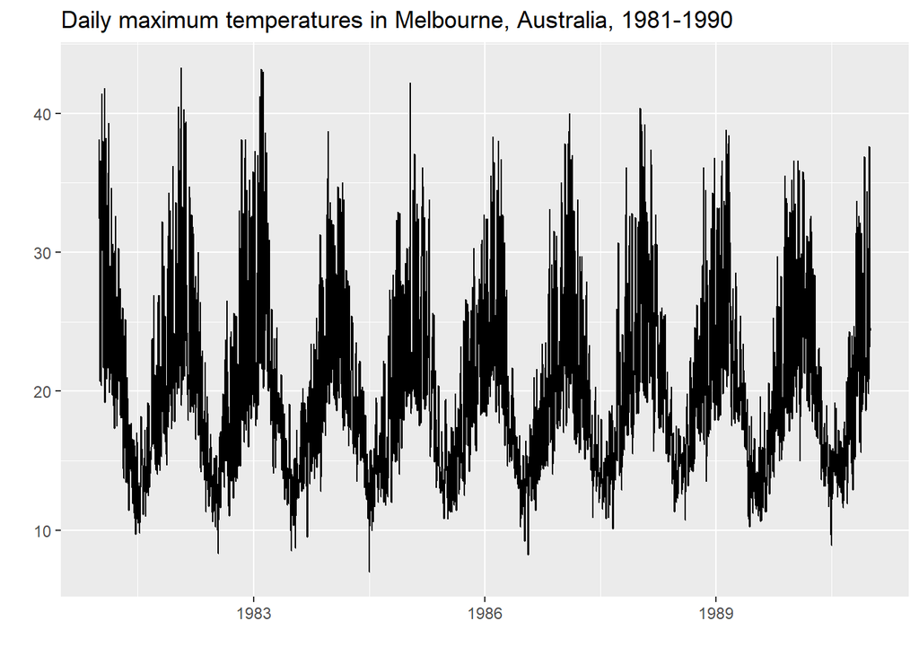

```r
autoplot(ts_2, main = "Daily maximum temperatures in Melbourne, Australia, 1981-1990")
```

Por otro lado, podemos notar que tenemos una tendencia aditiva pues los datos se comportan de una manera lineal. Por último, se puede observar que tiene ciclo estacional con periocidad de cada 365 dias, lo cual podemos corroborar con los gráficos ´acf´ ´pacf´:

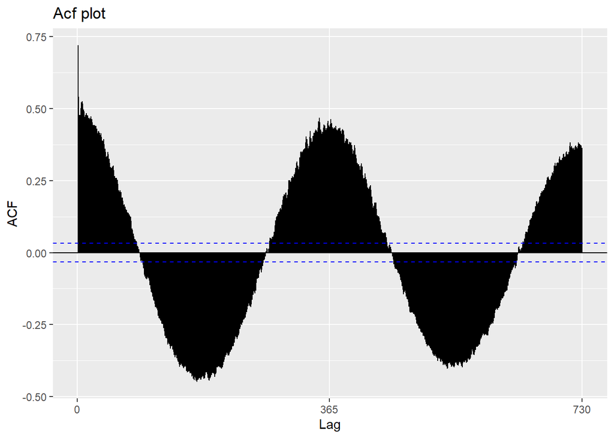

```r
ggAcf(ts_2, main="Acf plot")
```

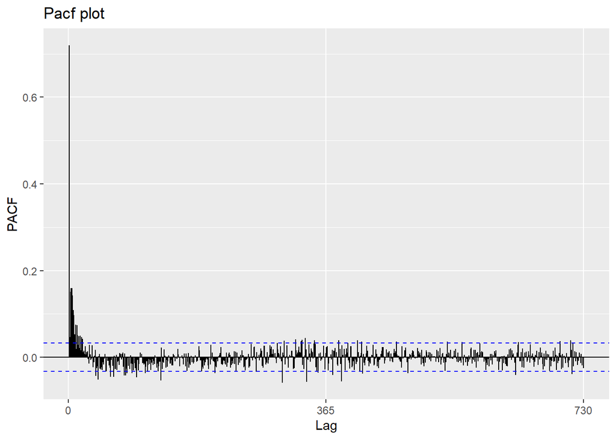

```r
ggPacf(ts_2, main="Pacf plot")
```

## Identificación de los datos faltantes

```r
sum(is.na(ts_2))
```

```
## [1] 0
```

Podemos notar que la serie de tiempo no contiene datos faltantes, por lo que no es necesario imputar.

## Descomposiciones

De acuerdo con los diferentes opciones para la descomposición clásica de la serie de tiempo, optamos por utilizar un modelo de regresión para obtener la tendencia y/o ciclos estacionales que pueda tener la serie.

Como dijimos en el punto anterior, nos parece que se comporta de manera lineal, sin embargo no estamos completamente seguros. Por lo anterior, podemos ajustar en el modelo de regresión lineal un cierto comportamiento polinomial, es decir:

```r
t= time(ts_2)-1981
M = factor(cycle(ts_2))

t2= t^2
t3= t^3
t4= t^4
t5= t^5
t6= t^6
t7= t^7
t8= t^8
t9= t^9
t10= t^10
t11= t^11

#ajuste del modelo
reg <- lm( ts_2 ~ 0 + t + t2+ t3+ t4+ t5 + t6 + t7 + t8 + t9 + M , na.action=NULL )
anova(reg)
```

```
## Analysis of Variance Table
##
## Response: ts_2
##             Df  Sum Sq Mean Sq   F value    Pr(>F)
## t            1 1088616 1088616 59315.431 < 2.2e-16 ***
## t2           1  192907  192907 10510.913 < 2.2e-16 ***
## t3           1   70096   70096  3819.299 < 2.2e-16 ***
## t4           1   36693   36693  1999.286 < 2.2e-16 ***
## t5           1   19333   19333  1053.380 < 2.2e-16 ***
## t6           1    7838    7838   427.047 < 2.2e-16 ***
## t7           1    9833    9833   535.790 < 2.2e-16 ***
## t8           1    1863    1863   101.525 < 2.2e-16 ***
## t9           1    4058    4058   221.121 < 2.2e-16 ***
## M          365  106127     291    15.843 < 2.2e-16 ***
## Residuals 3276   60124      18
## ---
## Signif. codes:  0 '***' 0.001 '**' 0.01 '*' 0.05 '.' 0.1 ' ' 1
```

```r
summary(reg)
```

```
##
## Call:
## lm(formula = ts_2 ~ 0 + t + t2 + t3 + t4 + t5 + t6 + t7 + t8 +
##     t9 + M, na.action = NULL)
##
## Residuals:
##      Min       1Q   Median       3Q      Max
## -11.1126  -2.6392  -0.4019   2.0122  17.2340
##
## Coefficients:
##        Estimate Std. Error t value Pr(>|t|)
## t    -2.376e+01  4.151e+00  -5.724 1.13e-08 ***
## t2    4.408e+01  7.670e+00   5.747 9.92e-09 ***
## t3   -3.743e+01  6.532e+00  -5.731 1.09e-08 ***
## t4    1.708e+01  3.018e+00   5.659 1.66e-08 ***
## t5   -4.542e+00  8.181e-01  -5.552 3.05e-08 ***
## t6    7.252e-01  1.337e-01   5.424 6.27e-08 ***
## t7   -6.840e-02  1.295e-02  -5.280 1.37e-07 ***
## t8    3.509e-03  6.845e-04   5.127 3.12e-07 ***
## t9   -7.545e-05  1.519e-05  -4.967 7.14e-07 ***
## M1    2.851e+01  1.509e+00  18.885  < 2e-16 ***
## M2    2.941e+01  1.510e+00  19.480  < 2e-16 ***
## M3    3.000e+01  1.510e+00  19.863  < 2e-16 ***
## M4    2.628e+01  1.511e+00  17.399  < 2e-16 ***
## M5    2.667e+01  1.511e+00  17.650  < 2e-16 ***
## M6    2.880e+01  1.511e+00  19.052  < 2e-16 ***
## M7    3.053e+01  1.512e+00  20.195  < 2e-16 ***
## M8    3.066e+01  1.512e+00  20.273  < 2e-16 ***
## M9    2.968e+01  1.513e+00  19.624  < 2e-16 ***
## M10   2.890e+01  1.513e+00  19.101  < 2e-16 ***
## M11   3.039e+01  1.513e+00  20.084  < 2e-16 ***
## M12   2.975e+01  1.514e+00  19.653  < 2e-16 ***
## M13   3.066e+01  1.514e+00  20.247  < 2e-16 ***
## M14   3.331e+01  1.514e+00  21.995  < 2e-16 ***
## M15   3.096e+01  1.515e+00  20.435  < 2e-16 ***
## M16   3.092e+01  1.515e+00  20.407  < 2e-16 ***
## M17   2.704e+01  1.516e+00  17.839  < 2e-16 ***
## M18   2.822e+01  1.516e+00  18.617  < 2e-16 ***
## M19   2.752e+01  1.516e+00  18.148  < 2e-16 ***
## M20   2.973e+01  1.517e+00  19.604  < 2e-16 ***
```

[output cut: 336 more lines]

```
## M357  2.807e+01  1.548e+00  18.129  < 2e-16 ***
## M358  2.863e+01  1.548e+00  18.490  < 2e-16 ***
## M359  2.973e+01  1.548e+00  19.199  < 2e-16 ***
## M360  2.649e+01  1.549e+00  17.106  < 2e-16 ***
## M361  2.822e+01  1.549e+00  18.222  < 2e-16 ***
## M362  2.704e+01  1.549e+00  17.459  < 2e-16 ***
## M363  3.081e+01  1.549e+00  19.892  < 2e-16 ***
## M364  3.172e+01  1.549e+00  20.479  < 2e-16 ***
## M365  3.224e+01  1.549e+00  20.813  < 2e-16 ***
## ---
## Signif. codes:  0 '***' 0.001 '**' 0.01 '*' 0.05 '.' 0.1 ' ' 1
##
## Residual standard error: 4.284 on 3276 degrees of freedom
## Multiple R-squared:  0.9624, Adjusted R-squared:  0.9581
## F-statistic:   224 on 374 and 3276 DF,  p-value: < 2.2e-16
```

Apoyándonos en el resumen de los datos con base en la regresión lineal que se hizo, se aprecia que el modelo es considerablemente bueno pues $R^2 = 0.9624$

Para visualizar la regresión, proseguimos a contrastar los resultados del ajuste contra los datos originales mediante una gráfica.

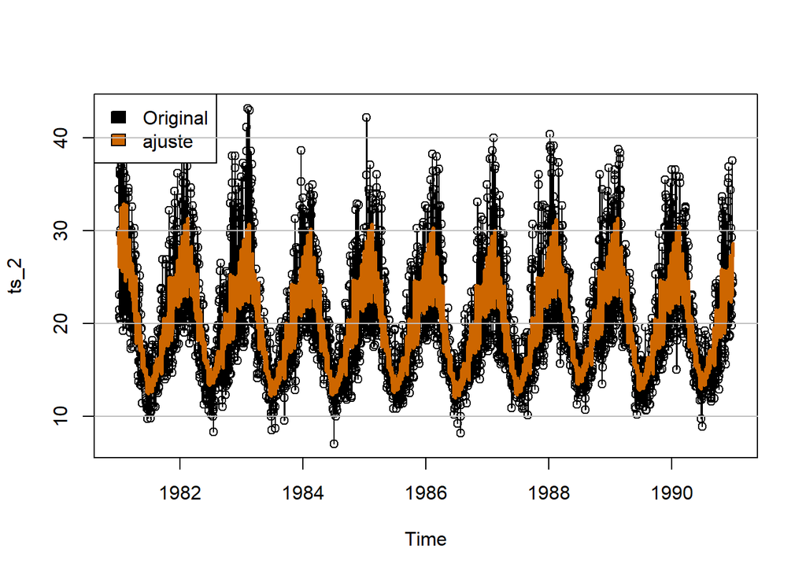

```r
plot(ts_2, type = "o")
lines(fitted(reg), col = "#CD6600", lwd = 3)
legend(x = "topleft", c("Original", "ajuste"), fill = c("black", "#CD6600"))

grid(nx = NA, ny = NULL, lty = 1, col = "gray", lwd = 1)
```

De lo anterior, podemos obtener la tendencia y el ciclo estacional de la serie de tiempo.

$\textbf{Tendencia}$

Para obtener la tendencia debemos excluir el ciclo estacional de la serie de tiempo ($M$) de la siguiente manera:

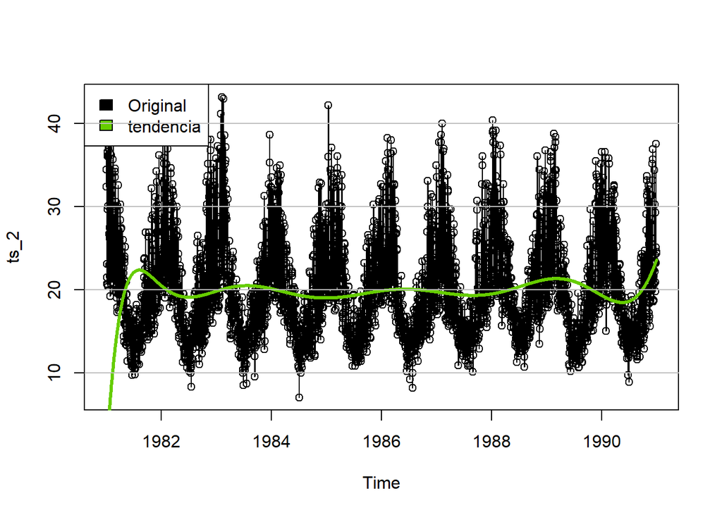

```r
#regresion sin tendencia
reg_tend <- lm( ts_2 ~ 0+ t + t2+ t3+ t4+ t5 + t6 + t7 + t8 + t9 + t10 , na.action=NULL )

#Graficamos los resultados
plot(ts_2, type = "o")
lines(fitted(reg_tend), col = "#66CD00", lwd = 3)
legend(x = "topleft", c("Original", "tendencia"), fill = c("black", "#66CD00"))

grid(nx = NA, ny = NULL, lty = 1, col = "gray", lwd = 1)
```

$\textbf{Ciclo Estacional}$

Para obtener el ciclo estacional anularemos todas las variables de timpo que se utilizaron en la regresión lineal y así quedarnos solo con el ciclo.

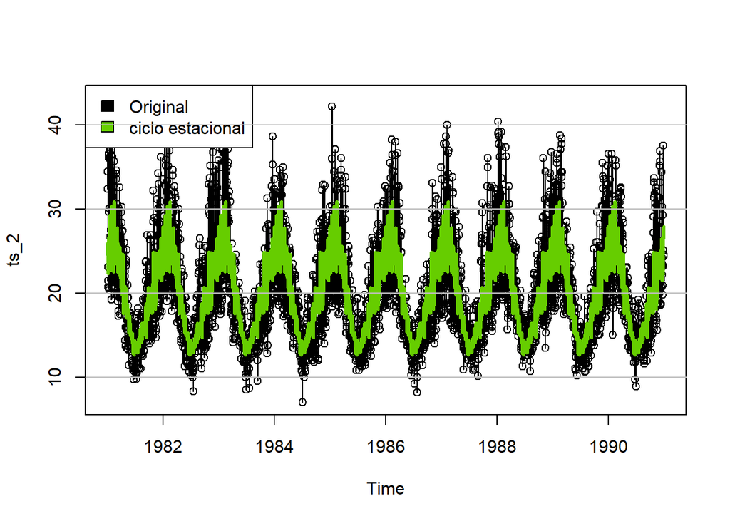

```r
#ajuste de la regresion
reg_cicl <- lm( ts_2 ~ 0 + M , na.action = NULL)

#Graficamos los resultados
plot(ts_2, type = "o")
lines(fitted(reg_cicl), col = "#66CD00", lwd = 3)
legend(x = "topleft", c("Original", "ciclo estacional"), fill = c("black", "#66CD00"))

grid(nx = NA, ny = NULL, lty = 1, col = "gray", lwd = 1)
```

## Ajuste de la serie de tiempo

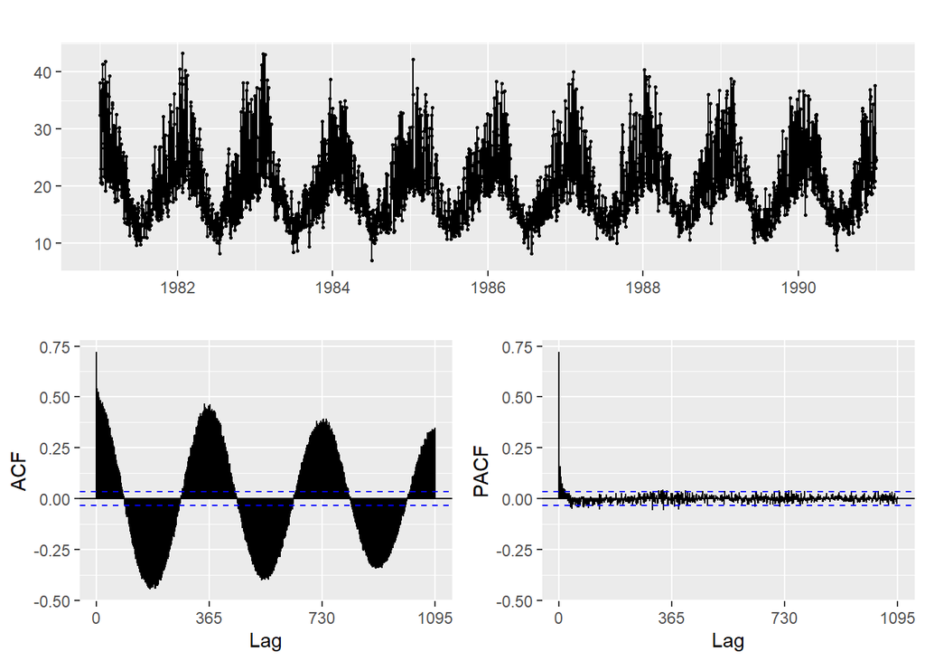

```r
ggtsdisplay(ts_2)
```

A partir del ´´ACF´´ y el ´´PACF´´ podemos determinar que el modelo adecuado para esta serie de tiempo podría ser un $AR$. Antes de realizar el ajuste, debemos ver si los datos cumplen con los supuestos de normalidad, varianza constante, independencia y estacionariedad, y partir de esto obtener el mejor modelo.

### Análisis de los supuestos

$\textbf{Normalidad}$

Observamos el $p-value$ resultante de la prueba de Anderson-Darling y la respectiva gráfica ´´qqplot´´:

```r
ad.test(ts_2)
```

```
##
##  Anderson-Darling normality test
##
## data:  ts_2
## A = 64.429, p-value < 2.2e-16
```

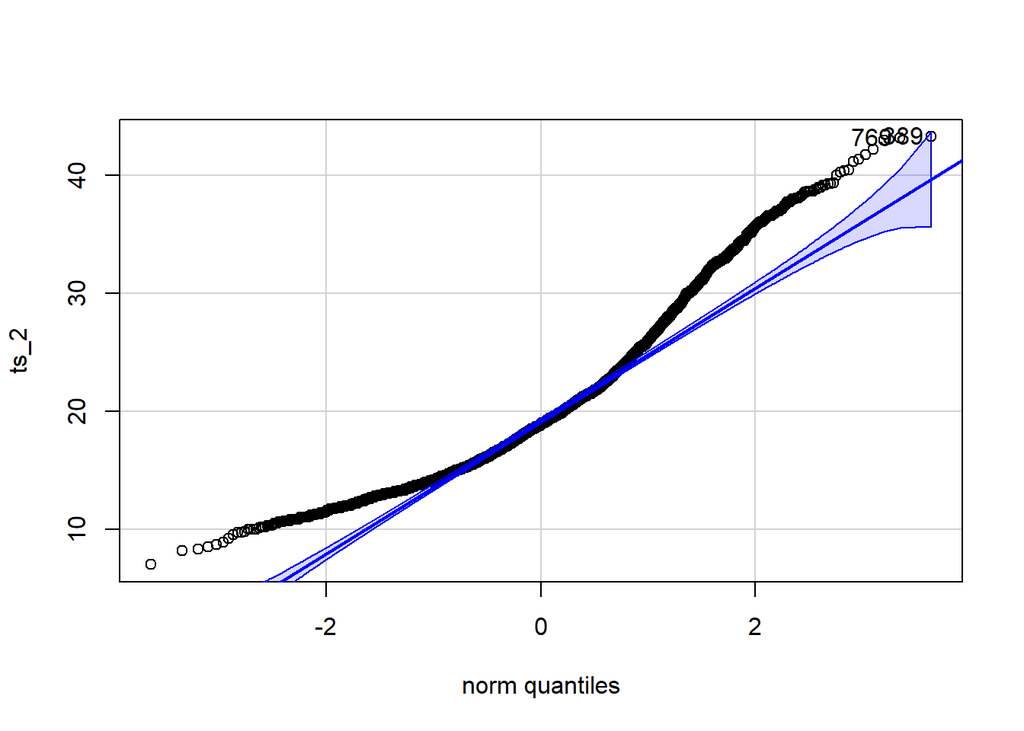

```
## [1] 389 769
```

```r
qqPlot(ts_2)
```

Con la prueba de normalidad anterior, tenemos un p- value < $2.2 e^{-16}$ por lo que no tenemos suficiente evidencia para aceptar $H_0$, de tal manerapodemos asumir que no se cumple la nornalidad

$\textbf{Varianza constante}$

```r
Y <- as.numeric(ts_2)
X <- 1:length(ts_2)
bptest(Y ~ X)
```

```
##
##  studentized Breusch-Pagan test
##
## data:  Y ~ X
## BP = 10.448, df = 1, p-value = 0.001228
```

```r
ncvTest(lm(Y~X))
```

```
## Non-constant Variance Score Test
## Variance formula: ~ fitted.values
## Chisquare = 13.61731, Df = 1, p = 0.00022411
```

En la primer prueba obtuvimos un p- value = 0.00122, con lo que podemos decir que no hay evidencia suficiente para aceptar $H_0$, por lo tanto no podemos decir que tenemos varianza constante; asimismo, en la segunda prueba obtenemos un p-value muy pequeño.

$\textbf{Independencia}$

Realizamos una prueba para la correlación de los datos para algunos valores específicos

```r
Box.test(ts_2)
```

```
##
##  Box-Pierce test
##
## data:  ts_2
## X-squared = 1893.1, df = 1, p-value < 2.2e-16
```

```r
Box.test(ts_2,lag=1*365)
```

```
##
##  Box-Pierce test
##
## data:  ts_2
## X-squared = 139076, df = 365, p-value < 2.2e-16
```

```r
Box.test(ts_2,lag=2*365)
```

```
##
##  Box-Pierce test
##
## data:  ts_2
## X-squared = 246073, df = 730, p-value < 2.2e-16
```

```r
Box.test(ts_2,lag=3*365)
```

```
##
##  Box-Pierce test
##
## data:  ts_2
## X-squared = 328349, df = 1095, p-value < 2.2e-16
```

```r
Box.test(ts_2,lag=4*365)
```

```
##
##  Box-Pierce test
##
## data:  ts_2
## X-squared = 391079, df = 1460, p-value < 2.2e-16
```

```r
Box.test(ts_2,lag=5*365)
```

```
##
##  Box-Pierce test
##
## data:  ts_2
## X-squared = 438236, df = 1825, p-value < 2.2e-16
```

De acuerdo con las diferentes pruebas, ningún lag pasa la prueba de independencia.

$\textbf{Estacionariedad}$

```r
adf.test(ts_2)
```

```
##
##  Augmented Dickey-Fuller Test
##
## data:  ts_2
## Dickey-Fuller = -5.4075, Lag order = 15, p-value = 0.01
## alternative hypothesis: stationary
```

Con la prueba de Dickey Fuller obtuvimos una p-value = 0.01, por lo que no hay evidencia suficiente para aceptar $H_0$, por lo que optamos con la prueba alternativa, en otras palabras, la serie es estacionaria

Con base a los resultados de los supuestos se puede ver que es necesario aplicarle una transformación a los datos. Proponemos trabajar con un ciclo de 12 en lugar de uno de 365. De tal manera, procedemos de la siguiente manera:

```r
Yt <- c()
t <- c()
u <- c()
for(i in 1:121){
  for(j in 1:30){
  t[j]= ts_2[(i-1)*30 + j]
  }
  Yt[i] = max(t)}
for(j in 1:20){
  u[j]= ts_2[(121)*30 + j]
}
Yt[122] <- max(u)
Yt
```

```
##   [1] 41.8 39.3 32.6 30.3 25.2 17.7 18.2 19.2 26.9 32.2 31.2 36.2 43.3 40.3 34.7
##  [16] 30.0 22.9 19.6 16.0 22.6 26.5 25.6 38.1 38.1 37.3 43.2 38.6 25.9 24.6 18.4
##  [31] 19.1 19.2 20.2 23.4 31.3 32.7 38.7 34.7 35.0 28.7 23.5 22.2 18.3 19.5 22.2
##  [46] 27.3 32.3 32.9 30.3 42.2 33.5 36.1 33.8 21.5 19.4 17.4 19.8 26.6 27.5 30.3
##  [61] 32.7 35.5 38.3 36.7 27.3 21.7 16.8 17.6 21.0 23.4 27.0 33.1 35.0 37.8 40.0
##  [76] 33.8 29.7 23.3 20.3 18.0 19.0 30.7 26.8 36.1 32.8 40.4 39.2 37.4 29.0 25.5
##  [91] 20.3 17.5 19.8 22.4 26.7 36.1 34.3 36.8 38.8 38.4 28.5 25.4 19.4 16.6 19.6
## [106] 20.6 26.1 29.7 35.5 36.6 36.6 35.8 32.6 23.1 19.3 16.2 19.2 20.7 24.3 33.7
## [121] 36.9 37.6
```

```r
ts <- ts(Yt,start = c(1981,1), end = c(1991,2), frequency = 12)
```

Con esto tenemos una serie de tiempo con observaciones mensuales por lo que tendríamos un período de 12 con el que será más fácil trabajar.

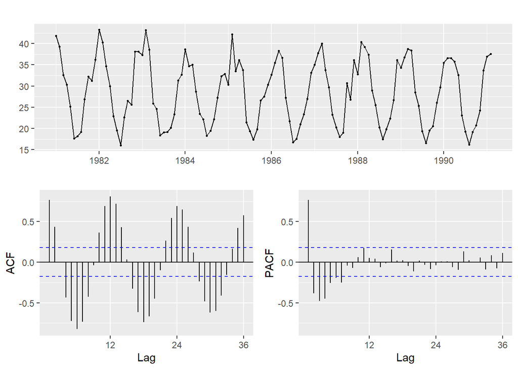

```r
# Observamos la gráfica de los datos transformados
ggtsdisplay(ts)
```

Después, utilizamos la función ´auto.arima()´ para ver un posible modelo que se acople a nuestros datos:

```r
auto.arima(ts)
```

```
## Series: ts
## ARIMA(0,0,0)(0,1,1)[12]
##
## Coefficients:
##          sma1
##       -0.4470
## s.e.   0.0844
##
## sigma^2 = 9.465:  log likelihood = -280.54
## AIC=565.07   AICc=565.18   BIC=570.47
```

Con lo anterior, probamos el siguiente modelo

```r
mod1 <- arima(ts, order = c(p=0, d=0, q=0), seasonal = list(order = c(P=0, D=1, Q=1), period = 12))
mod1
```

```
##
## Call:
## arima(x = ts, order = c(p = 0, d = 0, q = 0), seasonal = list(order = c(P = 0,
##     D = 1, Q = 1), period = 12))
##
## Coefficients:
##          sma1
##       -0.4470
## s.e.   0.0844
##
## sigma^2 estimated as 9.379:  log likelihood = -280.54,  aic = 565.07
```

### Supuestos del modelo

Ahora que tenemos el modelo, comprobaremos que se cumplen los siguientes supuestos:

$\textbf{Normalidad}$

```r
ad.test(mod1$residuals)
```

```
##
##  Anderson-Darling normality test
##
## data:  mod1$residuals
## A = 1.0985, p-value = 0.006774
```

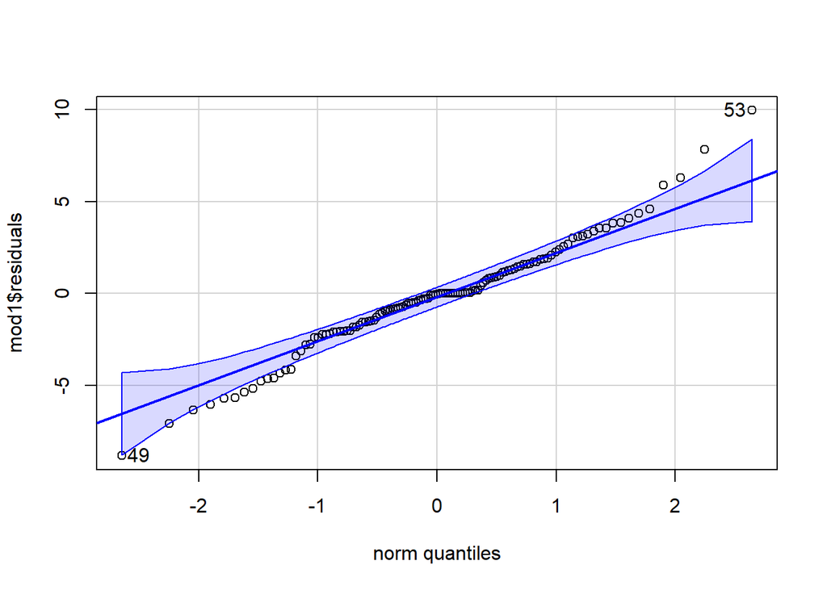

```
## [1] 53 49
```

```r
qqPlot(mod1$residuals)
```

Con esto podemos ver que este modelo no cumple con el supuesto de normalidad

$\textbf{Varianza constante}$

```r
Y <- as.numeric(mod1$residuals)
X <- 1:length(mod1$residuals)
bptest(Y ~ X)
```

```
##
##  studentized Breusch-Pagan test
##
## data:  Y ~ X
## BP = 0.80011, df = 1, p-value = 0.3711
```

```r
ncvTest(lm(Y~X))
```

```
## Non-constant Variance Score Test
## Variance formula: ~ fitted.values
## Chisquare = 1.319565, Df = 1, p = 0.25067
```

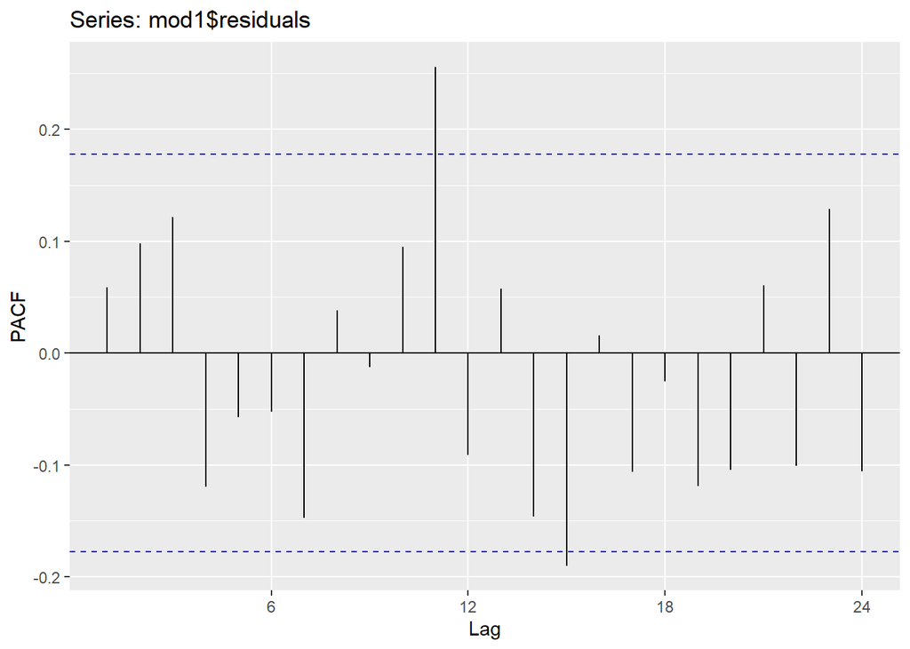

```r
ggPacf(mod1$residuals)
```

Con esto vemos que el modelo SI cumple con el supuesto de varianza constante.

$\textbf{Independencia}$

```r
Box.test(mod1$residuals)
```

```
##
##  Box-Pierce test
##
## data:  mod1$residuals
## X-squared = 0.41796, df = 1, p-value = 0.518
```

```r
Box.test(mod1$residuals,lag=1*12)
```

```
##
##  Box-Pierce test
##
## data:  mod1$residuals
## X-squared = 19.925, df = 12, p-value = 0.06851
```

```r
Box.test(mod1$residuals,lag=2*12)
```

```
##
##  Box-Pierce test
##
## data:  mod1$residuals
## X-squared = 42.401, df = 24, p-value = 0.01163
```

```r
Box.test(mod1$residuals,lag=3*12)
```

```
##
##  Box-Pierce test
##
## data:  mod1$residuals
## X-squared = 55.575, df = 36, p-value = 0.01963
```

```r
Box.test(mod1$residuals,lag=4*12)
```

```
##
##  Box-Pierce test
##
## data:  mod1$residuals
## X-squared = 64.983, df = 48, p-value = 0.05164
```

```r
Box.test(mod1$residuals,lag=5*12)
```

```
##
##  Box-Pierce test
##
## data:  mod1$residuals
## X-squared = 72.051, df = 60, p-value = 0.137
```

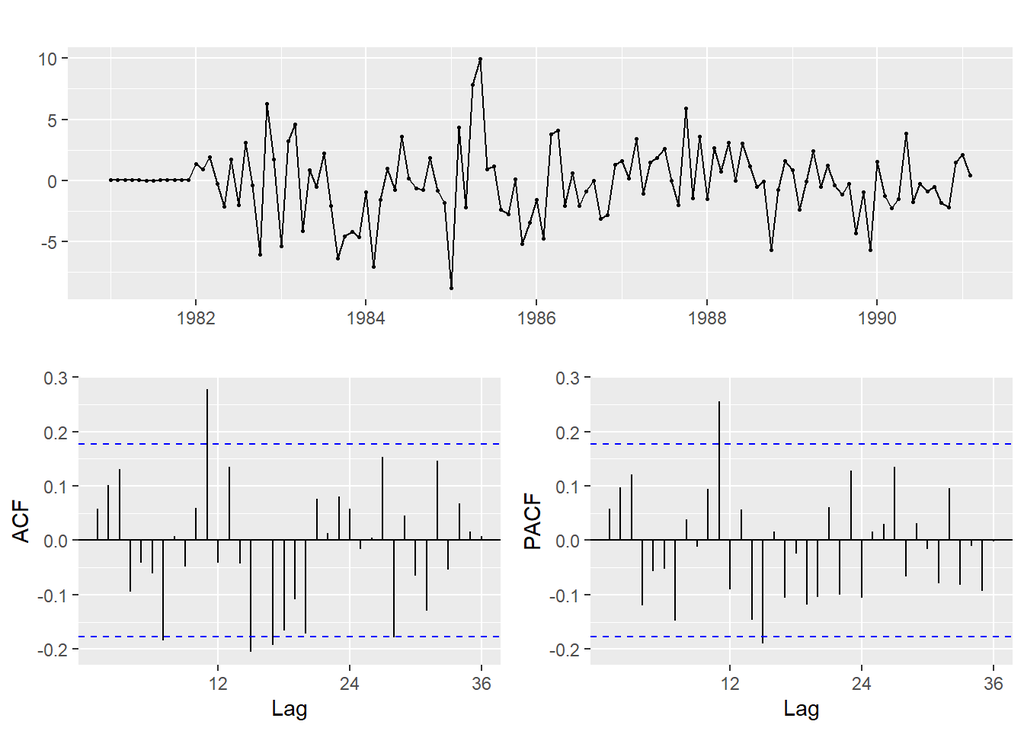

```r
ggtsdisplay(mod1$residuals)
```

Podemos ver que para lag 24 y 36 no se cumple con la independencia, sin embargo, para los demás si se cumple. De esto podemos concluir que habría que hacer algún ajuste al modelo.

$\textbf{Estacionariedad}$

```r
adf.test(mod1$residuals)
```

```
##
##  Augmented Dickey-Fuller Test
##
## data:  mod1$residuals
## Dickey-Fuller = -4.7798, Lag order = 4, p-value = 0.01
## alternative hypothesis: stationary
```

Por último, este modelo si cumple con el supuesto de estacionariedad.

Ajustaremos un nuevo modelo, para poder modelar mejor la dependencia.

```r
mod2 <- arima(ts, order = c(p=0, d=0, q=0), seasonal = list(order = c(P=1, D=1, Q=1), period = 12))
mod2
```

```
##
## Call:
## arima(x = ts, order = c(p = 0, d = 0, q = 0), seasonal = list(order = c(P = 1,
##     D = 1, Q = 1), period = 12))
##
## Coefficients:
##          sar1     sma1
##       -0.1783  -0.2993
## s.e.   0.2125   0.2104
##
## sigma^2 estimated as 9.314:  log likelihood = -280.2,  aic = 566.4
```

### Supuestos del modelo

Ahora que tenemos el modelo, comprobaremos que se cumplen los siguientes supuestos.

$\textbf{Normalidad}$

```r
ad.test(mod2$residuals)
```

```
##
##  Anderson-Darling normality test
##
## data:  mod2$residuals
## A = 1.0483, p-value = 0.009021
```

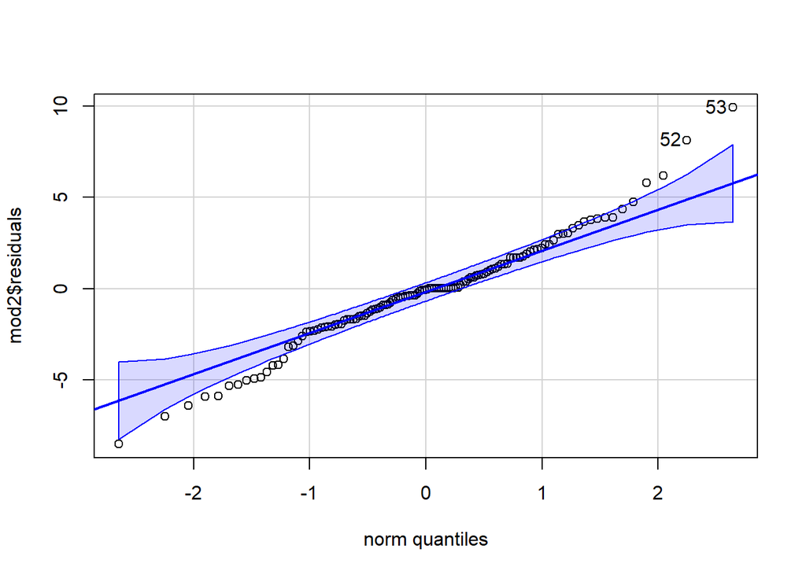

```
## [1] 53 52
```

```r
qqPlot(mod2$residuals)
```

Con estas pruebas podemos ver que ningún modelo trabajado cumple con normalidad.

$\textbf{Varianza constante}$

```r
Y <- as.numeric(mod2$residuals)
X <- 1:length(mod2$residuals)
bptest(Y ~ X)
```

```
##
##  studentized Breusch-Pagan test
##
## data:  Y ~ X
## BP = 0.73848, df = 1, p-value = 0.3901
```

```r
ncvTest(lm(Y~X))
```

```
## Non-constant Variance Score Test
## Variance formula: ~ fitted.values
## Chisquare = 1.217163, Df = 1, p = 0.26992
```

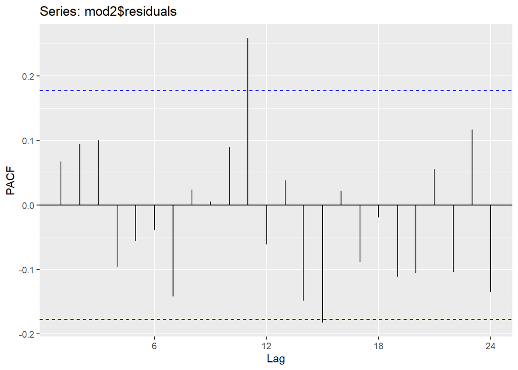

```r
ggPacf(mod2$residuals)
```

Nos arroja que cumple con tener varianza constante.

$\textbf{Independencia}$

```r
Box.test(mod2$residuals)
```

```
##
##  Box-Pierce test
##
## data:  mod2$residuals
## X-squared = 0.55036, df = 1, p-value = 0.4582
```

```r
Box.test(mod2$residuals,lag=1*12)
```

```
##
##  Box-Pierce test
##
## data:  mod2$residuals
## X-squared = 17.722, df = 12, p-value = 0.1244
```

```r
Box.test(mod2$residuals,lag=2*12)
```

```
##
##  Box-Pierce test
##
## data:  mod2$residuals
## X-squared = 35.942, df = 24, p-value = 0.0556
```

```r
Box.test(mod2$residuals,lag=3*12)
```

```
##
##  Box-Pierce test
##
## data:  mod2$residuals
## X-squared = 47.556, df = 36, p-value = 0.0942
```

```r
Box.test(mod2$residuals,lag=4*12)
```

```
##
##  Box-Pierce test
##
## data:  mod2$residuals
## X-squared = 55.581, df = 48, p-value = 0.2108
```

```r
Box.test(mod2$residuals,lag=5*12)
```

```
##
##  Box-Pierce test
##
## data:  mod2$residuals
## X-squared = 63.029, df = 60, p-value = 0.3697
```

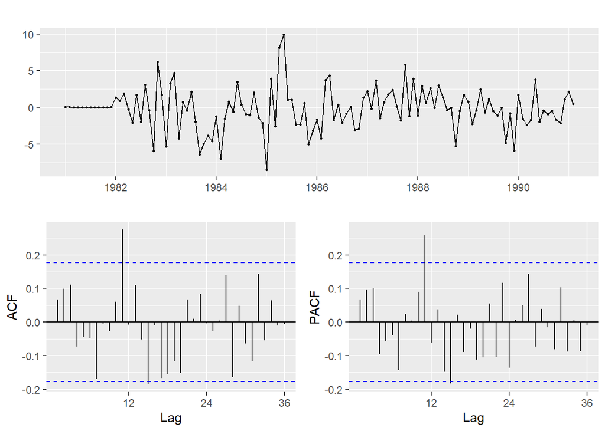

```r
ggtsdisplay(mod2$residuals)
```

Podemos ver que con este cambio en el modelo ya se cumple este supuesto para todos los lags que revisamos.

$\textbf{Estacionariedad}$

```r
adf.test(mod2$residuals)
```

```
##
##  Augmented Dickey-Fuller Test
##
## data:  mod2$residuals
## Dickey-Fuller = -4.7413, Lag order = 4, p-value = 0.01
## alternative hypothesis: stationary
```

Por último, tenemos que se cumple la estacionariedad.

Con este modelo se realiza un buen ajuste, ya que cumple con todos los supuestos, a excepción de la normalidad, pero se cumplen los primordiales.

```r
Box.test(mod2$residuals,type = "Ljung-Box") # nos interesan p-value > alpha
```

```
##
##  Box-Ljung test
##
## data:  mod2$residuals
## X-squared = 0.56401, df = 1, p-value = 0.4527
```

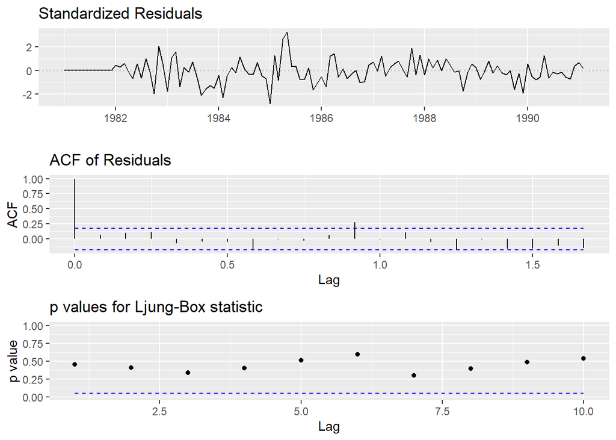

```r
ggtsdiag(mod2)
```

## Prónostico

Después, realizamos la predicción a un año con los intervalos de predicción visibles:

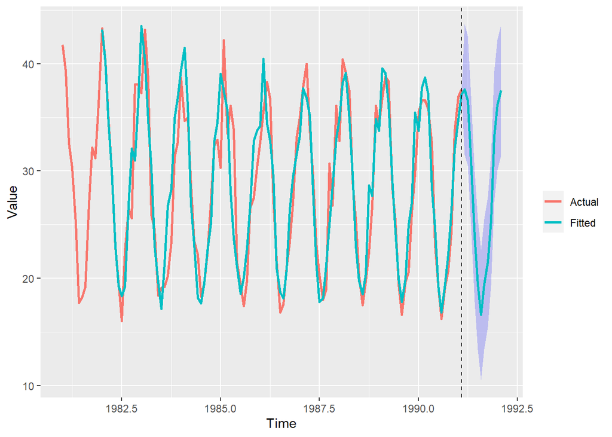

```r
HWplot3 (ts, n.ahead = 12)
```